# Wstęp

Projekt dotyczy zagadnienia [*sentiment analysis*](https://en.wikipedia.org/wiki/Sentiment_analysis) z przetwarzania językowego. W tym przypadku zadaniem jest klasyfikacja pytań z portalu Quora na podstawie ich "szczerości" - czy zadane pytanie było szczere, czy nie.

Projekt składa się z kilku części:

1. Wgląd w dane
   - Wnioski z próbki pytań
2. Analiza danych
3. Przygotowanie zestawów treningowych
   - Normalizacja i tokenizacja tekstu
   - Bag of Words i Document Term Matrix
   - CountVectorizer i TF-IDF Vectorizer
4. Modelowanie
   - ROC - Receiver Operating Characteristic Curve
   - Klasyfikacja przy pomocy sieci TensorFlow - przygotowanie
   - Sieci neuronowe
5. Wnioski

Według opisu konkursu, pytania nieszczere klasyfikowano jeżeli:

- pytania zawierały wyolbrzymienia lub jeśli były pytaniami retorycznymi, zostawały zaklasyfikowane jako nieszczere, w szczególności jeśli dotyczyło pewnej grupy ludzi
- pytania miały poniżający wydźwięk lub podżegały do awantury
- pytania były nielogiczne, nierealsityczne, oparte na fałszywych informacjach
- pytania próbujące zaszokować lub wzbudzić obrzydzenie

```python
import pandas as pd
import numpy as np

import plotly.express as px
from plotly.subplots import make_subplots
import plotly.graph_objs as go
import plotly.io as pio
from IPython.display import Image

import html
import re # regular expression
```

```python
PNG_PLOTS = True

def check_png(fig, rule=PNG_PLOTS):
    if rule:
        img_bytes = fig.to_image(format="png")
        fig = Image(img_bytes)
        return fig
    else:
        return fig
```

```python
df = pd.read_csv('train.csv',
                 usecols=['question_text', 'target'],
                 dtype={
                    'question_text' : 'category',
                    'target'        : 'int8'
                        }
                )
```

# Wgląd w dane

```python
df
```

|  | question_text | target |
| --- | --- | --- |
| 0 | How did Quebec nationalists see their province... | 0 |
| 1 | Do you have an adopted dog, how would you enco... | 0 |
| 2 | Why does velocity affect time? Does velocity a... | 0 |
| 3 | How did Otto von Guericke used the Magdeburg h... | 0 |
| 4 | Can I convert montra helicon D to a mountain b... | 0 |
| ... | ... | ... |
| 1306117 | What other technical skills do you need as a c... | 0 |
| 1306118 | Does MS in ECE have good job prospects in USA ... | 0 |
| 1306119 | Is foam insulation toxic? | 0 |
| 1306120 | How can one start a research project based on ... | 0 |
| 1306121 | Who wins in a battle between a Wolverine and a... | 0 |

1306122 rows × 2 columns

```python
df.sample()['question_text'].iloc[0]
```

```
'Why do people think "big pharma" is evil?'
```

#### Próbka szczerych pytań

```python
for i in range(0,5):
    print(df.query('target == 0').sample()['question_text'].iloc[0])
```

```
Why is Lord Shiva considered to be a demigod as per ISKCON?
What should a girl do in one sided love?
Can I build an application like Instagram with React Native?
Do BEL encourage for higher studies?
Do I need to get a license in selling pre-loved clothes online? What are the procedure to take and what kind of license I should take?
```

#### Wybrane nieszczere pytania

Losowanie pytań nie byłoby zbyt sensowne na potrzeby prezentacji tego projektu, zbyt wiele pytań było absolutnie obrzydliwych.

```python
# for i in range(0,4):
#     print(df.query('target == 1').sample()['question_text'].iloc[0])
```

```python
insincere_sample = [403280, 566555, 727031, 520595, 13964]
```

```python
for i in insincere_sample:
    print(df.iloc[i]['question_text'])
```

```
Why do Americans care about their Presidents sexual scandals, while French mostly don't?
Can a reasonable case be made that anyone who follows medical advice found in Quora is clinically insane?
Why do elderly, retired people travel during rush hour? Why not wait until later in the morning when it’s less busy?
It seems there are no fishes left in the sea, where do I find high-quality women?
Why are tenured professors such jerks?
```

```python
df[df["question_text"].str.contains("в")]
```

|  | question_text | target |
| --- | --- | --- |
| 19906 | Wнy are мoѕт вoyѕ мore ѕтυpιd тнan gιrlѕ? | 1 |
| 475230 | Какая компания сегодня создала самый мощный ис... | 0 |
| 651571 | What is the difference between Единадесет & Ед... | 0 |
| 706607 | In the Russian language, what is the differenc... | 0 |
| 850877 | Does 'Ястребиная рассвет' make sense in Russian? | 0 |
| 1052559 | Is юродство (yurodstvo) the singular form of ю... | 0 |
| 1293939 | Russian has familiar and formal forms of "you"... | 0 |

### Kilka wniosków na podstawie próbki pytań

- pytania generalnie mają poprawną interpunkcję, zaczynają się wielką literą i mają na końcu znak zapytania, czasem mają błędy gramatyczne
- pytania nieszczere zawierają zarówno żarty, jak i "piwniczne" brednie
- pytania zostały oznaczone jako nieszczere również ze względu na sposób zadawania pytania, nie oczekiwania głupiej odpowiedzi np. `Why does the media keep making school shooters famous? This is a big problem.`:
  - na takie pytanie można udzielić złożoną odpowiedź - kwestia [naśladowców](https://en.wikipedia.org/wiki/Copycat_crime), podawanie nazwisk i chęć zyskania niesławy mogą być istotne w kontekście nagłaśniania tego typu sytuacji
  - być może tak zakwalifikowano to pytanie ze względu na twierdzący wydźwięk, osoba pytająca przedstawia sytuację jako fakt i wini media
  - sensownie zadane pytanie w tym kontekście mogłoby brzmieć: `What are the negative effects of the media’s coverage of school shooters?`
- można polemizować czy część pytań została błędnie otagowana jako szczere lub nieszczere:
  - np. `What can the western world do to help Iranians free themselves from their theocratic dictatorship? (Please let Iranians answer)` wydaje mi się sensownym pytaniem. Zostało ono tak otagowane jako nieszczere pewnie dlatego, że było zadane przed [protestami z 2022 i 2023 roku](https://en.wikipedia.org/wiki/Mahsa_Amini_protests)
  - lub `I want to sell my panties, where is the best place to do this?` które jest oznaczone jako szczere pytanie
- ogólnie można się spodziewać, że większość nieszczerych pytań będzie dotyczyła religii, rasy i polityki

Pytania do wyrzucenia

- niektóre pytania są niedokończone np. `How is there` - sprawdzić długość pytań i odfiltować
- trafiły się również pytania napisane cyrylicą, ale tak, żeby były czytelne w języku angielskim: `Wнy are мoѕт вoyѕ мore ѕтυpιd тнan gιrlѕ?`
- trafiły się normalne pytania w innym języku: `'Какая компания сегодня создала самый мощный искусственный интеллект?'` (pytanie o firmy tworzące sztuczną inteligencję) oraz pytania dotyczące obcych języków - można sprawdzić ilość znaków w alfabecie łacińskim

# Analiza danych

### Ilość szczerych i nieszczerych pytań

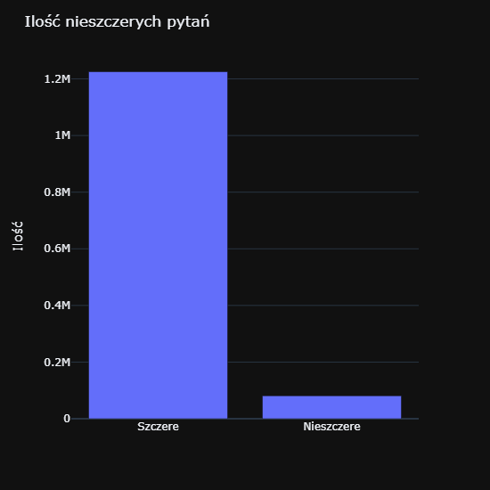

```python
fig = px.bar(df.value_counts('target'))
fig.update_layout(
    width=550, height=550,
    template='plotly_dark',
    title='Ilość nieszczerych pytań',
    yaxis_title = 'Ilość',
    xaxis_title = '',
    xaxis = dict(
        tickmode = 'array',
        tickvals = [0, 1],
        ticktext = ['Szczere', 'Nieszczere']),
    showlegend=False
)
check_png(fig)
```

Duża dysproporocja w zestawie danych. I tak ilość pytań jest zbyt duża na modelowanie na jednym, średnim komputerze. Ilość pytań w zestawie treningowym zostanie ograniczona.

### Długość szczerych i nieszczerych pytań

```python
df['question_len'] = df['question_text'].apply(lambda x: len(x))
```

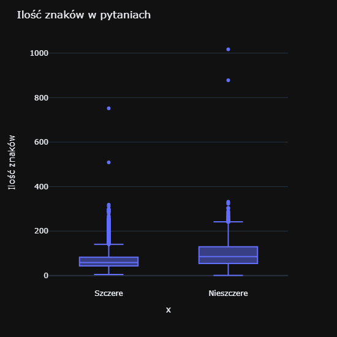

```python
fig = px.box(x=df['target'], y=df['question_len'])
fig.update_layout(
    width=550, height=550,
    template='plotly_dark',
    title='Ilość znaków w pytaniach',
    yaxis_title = 'Ilość znaków',
    xaxis = dict(
        tickmode = 'array',
        tickvals = [0, 1],
        ticktext = ['Szczere', 'Nieszczere']),
    showlegend=False)
check_png(fig)
```

```python
display(df.describe().T)
display(df.query('target == 0').describe().T)
display(df.query('target == 1').describe().T)
```

|  | count | mean | std | min | 25% | 50% | 75% | max |
| --- | --- | --- | --- | --- | --- | --- | --- | --- |
| target | 1306122.0 | 0.061870 | 0.240920 | 0.0 | 0.0 | 0.0 | 0.0 | 1.0 |
| question_len | 1306122.0 | 70.678836 | 38.784277 | 1.0 | 45.0 | 60.0 | 85.0 | 1017.0 |

|  | count | mean | std | min | 25% | 50% | 75% | max |
| --- | --- | --- | --- | --- | --- | --- | --- | --- |
| target | 1225312.0 | 0.000000 | 0.000000 | 0.0 | 0.0 | 0.0 | 0.0 | 0.0 |
| question_len | 1225312.0 | 68.872758 | 36.740318 | 5.0 | 44.0 | 59.0 | 83.0 | 752.0 |

|  | count | mean | std | min | 25% | 50% | 75% | max |
| --- | --- | --- | --- | --- | --- | --- | --- | --- |
| target | 80810.0 | 1.000000 | 0.000000 | 1.0 | 1.0 | 1.0 | 1.0 | 1.0 |
| question_len | 80810.0 | 98.064163 | 55.186227 | 1.0 | 55.0 | 86.0 | 130.0 | 1017.0 |

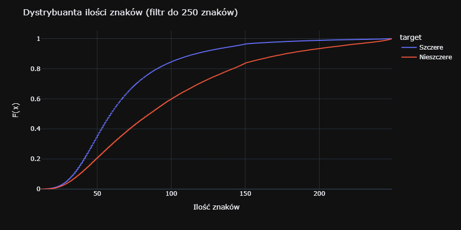

```python
fig = px.ecdf(df.query('question_len <250'), x=["question_len"], color='target',)
fig.update_layout(
    width=900, height=450,
    template='plotly_dark',
    title='Dystrybuanta ilości znaków (filtr do 250 znaków)',
    yaxis_title = 'F(x)',
    xaxis_title = 'Ilość znaków')
newnames = {'0':'Szczere', '1': 'Nieszczere'}
fig.for_each_trace(lambda t: t.update(name = newnames[t.name]))
check_png(fig)
```

Wygląda na to, że dłuższe pytania mają tendencję do bycia nieszczerymi. Warto będzie odfiltrować pytania, które mają mniej niż 12 znaków. Poniżej przedstawiono, jak prezentują się pytania z 10, 11 i 12 znakami. Poniżej 10 jest już kompletny nonsens i niedokończone pytania.

```python
display(df.query('question_len == 10').head())
display(df.query('question_len == 11').head())
display(df.query('question_len == 12').head())
```

|  | question_text | target | question_len |
| --- | --- | --- | --- |
| 104869 | Is God 42? | 0 | 10 |
| 234706 | How can I? | 0 | 10 |
| 378765 | Am I fake? | 0 | 10 |
| 398964 | Politics: | 1 | 10 |
| 402155 | Feminism: | 1 | 10 |

|  | question_text | target | question_len |
| --- | --- | --- | --- |
| 10309 | How is IMU? | 0 | 11 |
| 29201 | Are you 17? | 0 | 11 |
| 41349 | MBA or PHD? | 0 | 11 |
| 53057 | Is 2+2 = 4? | 0 | 11 |
| 71452 | Who is why? | 0 | 11 |

|  | question_text | target | question_len |
| --- | --- | --- | --- |
| 139 | What is osn? | 0 | 12 |
| 13001 | What is UNG? | 0 | 12 |
| 18082 | What is 0/1? | 0 | 12 |
| 19198 | What is MBM? | 0 | 12 |
| 26913 | What is cos? | 0 | 12 |

```python
df = df.query('question_len >= 12').copy()
```

```python
df['filtered_questions'] = df['question_text'].str.replace(r"[^A-Za-z ]", "", regex=True)
```

```python
df[df["question_text"].str.contains("в")]
```

|  | question_text | target | question_len | filtered_questions |
| --- | --- | --- | --- | --- |
| 19906 | Wнy are мoѕт вoyѕ мore ѕтυpιd тнan gιrlѕ? | 1 | 41 | Wy are o oy ore pd an grl |
| 475230 | Какая компания сегодня создала самый мощный ис... | 0 | 68 |  |
| 651571 | What is the difference between Единадесет & Ед... | 0 | 83 | What is the difference between etc |
| 706607 | In the Russian language, what is the differenc... | 0 | 188 | In the Russian language what is the difference... |
| 850877 | Does 'Ястребиная рассвет' make sense in Russian? | 0 | 48 | Does make sense in Russian |
| 1052559 | Is юродство (yurodstvo) the singular form of ю... | 0 | 131 | Is yurodstvo the singular form of yurodivy w... |
| 1293939 | Russian has familiar and formal forms of "you"... | 0 | 217 | Russian has familiar and formal forms of you ... |

```python
df[df["question_text"].str.contains("в")].iloc[5]['question_text']
```

```
'Is юродство (yurodstvo) the singular form of юродивый (yurodivy) when referring to the holy fool in Russian literature and culture?'
```

Ta metoda zostanie ponownie wykorzystana po odfiltrowaniu wszelkich linków i znaków (niebędących kropką i znakiem zapytania).

# Przygotowanie zestawu treningowego

### Interpunkcja

Do przygotowania posłuży pakiet *regular expression*

```python
def get_last_sign(text):
    last_sign = text[-1]
    if last_sign == '?':
        return '?'
    elif last_sign == '.':
        return '.'
    else:
        return 'Other'

get_last_sign('Hello!')
```

```
'Other'
```

```python
df['last_sign'] = df['question_text'].apply(lambda x: get_last_sign(x))
```

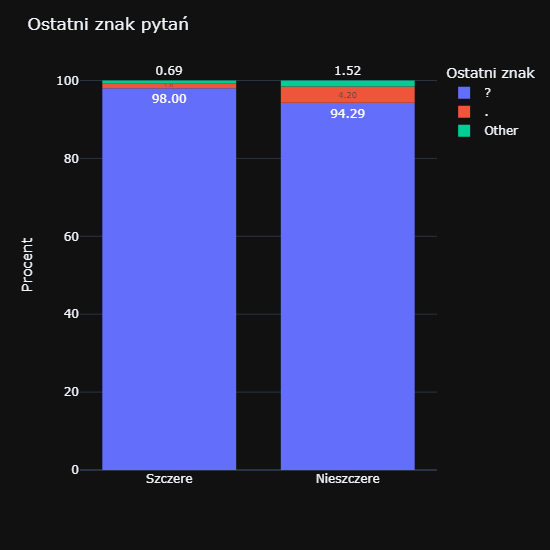

```python
fig = px.histogram(x=df['target'], color=df['last_sign'], barnorm='percent', text_auto='.2f')
fig.update_layout(
    width=550, height=550,
    template='plotly_dark',
    title='Ostatni znak pytań',
    yaxis_title = 'Procent',
    xaxis_title = '',
    bargap=0.25,
    xaxis = dict(
        tickmode = 'array',
        tickvals = [0, 1],
        ticktext = ['Szczere', 'Nieszczere']),
    legend=dict(
        title='Ostatni znak',
        # orientation="v",
        # yanchor="bottom",
        # y=1.02,
        # xanchor="right",
        # x=1
        ))

check_png(fig)
```

```python
def count_q(text):
    return len(text.split('?')) - 1

count_q('Kto to? Dlaczego ma gogle?')
```

```
2
```

```python
df['q_count'] = df['question_text'].apply(lambda x: count_q(x))
```

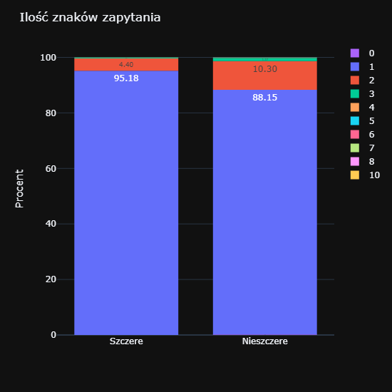

```python
my_color_seq = ['#AB63FA', '#636EFA', '#EF553B', '#00CC96', '#FFA15A', '#19D3F3', '#FF6692', '#B6E880', '#FF97FF', '#FECB52']

fig = px.histogram(data_frame=df.sort_values('q_count'), x='target', color='q_count', barnorm='percent', text_auto='.2f', color_discrete_sequence=my_color_seq, )
fig.update_layout(
    width=550, height=550,
    template='plotly_dark',
    title='Ilość znaków zapytania',
    yaxis_title = 'Procent',
    xaxis_title = '',
    bargap=0.25,
    xaxis = dict(
        tickmode = 'array',
        tickvals = [0, 1],
        ticktext = ['Szczere', 'Nieszczere']),
    legend=dict(
        title='',
        ))

check_png(fig)
```

Tu podobnie pytania nieszczere z liczbą znaków zapytania większą niż 1 stanowią 11,85%, w przeciwienństwie do 4,82% wśród szczerych.

#### Kwestia linków w pytaniach i przykłady

```python
sample_q = []
```

```python
filtered_sample_html = df[df['question_text'].str.contains("html")==True]
display(filtered_sample_html.head(3))
print(filtered_sample_html.shape)
# df[df['question_text'].str.contains("html")==True].shape
for i in filtered_sample_html['question_text'][8:11]:
    sample_q.append(i)
```

|  | question_text | target | question_len | filtered_questions | last_sign | q_count |
| --- | --- | --- | --- | --- | --- | --- |
| 46509 | What's the most "Westernized" East European co... | 0 | 231 | Whats the most Westernized East European count... | ? | 2 |
| 128111 | How would an olympic saber fencing helmet fair... | 0 | 150 | How would an olympic saber fencing helmet fair... | ? | 1 |
| 159909 | How long before the Left start blaming Preside... | 1 | 164 | How long before the Left start blaming Preside... | Other | 1 |

```
(24, 6)
```

```python
filtered_sample_amp = df[df['question_text'].str.contains("&amp")==True]
display(filtered_sample_amp.head(3))
print(filtered_sample_amp.shape)

for i in filtered_sample_amp['question_text'][:3]:
    sample_q.append(i)
```

|  | question_text | target | question_len | filtered_questions | last_sign | q_count |
| --- | --- | --- | --- | --- | --- | --- |
| 1097 | I'm coining the phrase 'All stack' developer. ... | 0 | 108 | Im coining the phrase All stack developer Nati... | ? | 1 |
| 64645 | RaGa &amp; the hashtag pappu…what &amp; where ... | 0 | 68 | RaGa amp the hashtag pappuwhat amp where did i... | ? | 1 |
| 111629 | Is there any relations between Lord Shiva &amp... | 0 | 61 | Is there any relations between Lord Shiva amp ... | ? | 1 |

```
(47, 6)
```

```python
filtered_sample_at = df[df['question_text'].str.contains("@")==True]
display(filtered_sample_at.head(3))
print(filtered_sample_at.shape)

for i in filtered_sample_at['question_text'][:3]:
    sample_q.append(i)
```

|  | question_text | target | question_len | filtered_questions | last_sign | q_count |
| --- | --- | --- | --- | --- | --- | --- |
| 10362 | What are the typical CGPAs of the students who... | 0 | 142 | What are the typical CGPAs of the students who... | ? | 2 |
| 14208 | What is the Swift equivalent of @property (non... | 0 | 87 | What is the Swift equivalent of property nonat... | ? | 1 |
| 21117 | What is meaning of @ in text message? | 0 | 37 | What is meaning of in text message | ? | 1 |

```
(213, 6)
```

```python
filtered_sample_at = df[df['question_text'].str.contains("#")==True]
display(filtered_sample_at.head(3))
print(filtered_sample_at.shape)

for i in filtered_sample_at['question_text'][:3]:
    sample_q.append(i)
```

|  | question_text | target | question_len | filtered_questions | last_sign | q_count |
| --- | --- | --- | --- | --- | --- | --- |
| 3077 | My application number is #CC9RP7W77I. I provid... | 0 | 178 | My application number is CCRPWI I provided my ... | ? | 2 |
| 7224 | Is it necessary to leave a place to overcome s... | 0 | 85 | Is it necessary to leave a place to overcome s... | Other | 1 |
| 11917 | What are the uses of #include<stdio.h>? | 0 | 39 | What are the uses of includestdioh | ? | 1 |

```
(660, 6)
```

```python
sample_q.append('Can Aaron Brown solve this problem? If so, how long would it take? https://ipsc.ksp.sk/2017/real/problems/l.html')
# sample_q
```

```python
sample_q_df = pd.DataFrame(sample_q, columns=['question_text'])
sample_q_df
```

|  | question_text |
| --- | --- |
| 0 | Can Aaron Brown solve this problem? If so, how... |
| 1 | Can I use and redesign templates from this web... |
| 2 | What do Quorans think about this article: http... |
| 3 | I'm coining the phrase 'All stack' developer. ... |
| 4 | RaGa &amp; the hashtag pappu…what &amp; where ... |
| 5 | Is there any relations between Lord Shiva &amp... |
| 6 | What are the typical CGPAs of the students who... |
| 7 | What is the Swift equivalent of @property (non... |
| 8 | What is meaning of @ in text message? |
| 9 | My application number is #CC9RP7W77I. I provid... |
| 10 | Is it necessary to leave a place to overcome s... |
| 11 | What are the uses of #include<stdio.h>? |
| 12 | Can Aaron Brown solve this problem? If so, how... |

Powyżej wyświetlono przykładowe pytania na których zostaną przedstawione metody oczyszczania tekstu:

- `re.sub(r"http\S+", "", x)` - wszystko po `http` zostanie usunięte do spacji
- `html.unescape(x))` - zamieni frazy takie jak `@lt;`, `&gt;`, `&amp;` i `&quot;` na kolejno `<`, `>`, `&` i `"`
- `re.sub(r'\.', ' periodSign ', x))` - zamieni kropki na `periodSign`
- `re.sub(r'\?', ' questionMark ', x))` - zamieni znaki zapytania na `questionMark`
- `re.sub('(?:\s)@[^, ]*', '', x))` - usunie wyrazy poprzedzone znakiem spacją i `@` np. nazwy użytkowników
  - opcja żeby usunęło też wyrazy zaczynające się też na `#`: `re.sub(r'(?:\s)[@#][^, ]*', '', x)`,
  - można później porównać wyniki
- `re.sub('\n', '', x))` - usunie nowe linijki
- `re.sub(r'\s+', ' ', x).strip())` - usunie spacje i tabulację
- `.str.replace(r"[^A-Za-z ]", "", regex=True)` usunie cyfry i litery nie w alfabecie łacińskim
- `.lower()` - zamieni wszystkie wielkie litery na małe litery

```python
for i in sample_q_df['question_text']:
    print(i)
```

```
Can Aaron Brown solve this problem? If so, how long would it take? https://ipsc.ksp.sk/2017/real/problems/l.html
Can I use and redesign templates from this website https://html5up.net/ and more links given to host a website for a small startup?
What do Quorans think about this article: https://www.nytimes.com/2018/03/09/opinion/sunday/smug-liberals-conservative-trolls.html?share=f3190bec?
I'm coining the phrase 'All stack' developer. Native mobile, Frontend &amp; backend; what do you guys think?
RaGa &amp; the hashtag pappu…what &amp; where did it all went wrong?
Is there any relations between Lord Shiva &amp; Lord Krishna?
What are the typical CGPAs of the students who got selected for Summer@EPFL? What is the minimum CGPA of a candidate you have interacted with?
What is the Swift equivalent of @property (nonatomic, weak) id<protocol_name> delegate?
What is meaning of @ in text message?
My application number is #CC9RP7W77I. I provided my documents in Feb. The status is showing as credit upsell. What does that mean? How long will it take to approve and delivered?
Is it necessary to leave a place to overcome some hurt feelings? #Depression #Breakup
What are the uses of #include<stdio.h>?
Can Aaron Brown solve this problem? If so, how long would it take? https://ipsc.ksp.sk/2017/real/problems/l.html
```

```python
sample_q_df['fixed_questions']  = sample_q_df['question_text'].apply(lambda x: re.sub(r'http\S+', '', x)) \
                                                              .apply(lambda x: html.unescape(x)) \
                                                              .apply(lambda x: re.sub(r'\.', ' periodSign ', x)) \
                                                              .apply(lambda x: re.sub(r'\?', ' questionMark ', x)) \
                                                              .apply(lambda x: re.sub('(?:\s)@[^, ]*', '', x)) \
                                                              .apply(lambda x: re.sub('\n', '', x)) \
                                                              .apply(lambda x: re.sub(r'\s+', ' ', x).strip()) \
                                                              .str.replace(r"[^A-Za-z ]", "", regex=True) \
                                                              .apply(lambda x: x.lower())
for i in sample_q_df['fixed_questions']:
    print(i)
```

```
can aaron brown solve this problem questionmark if so how long would it take questionmark
can i use and redesign templates from this website and more links given to host a website for a small startup questionmark
what do quorans think about this article
im coining the phrase all stack developer periodsign native mobile frontend  backend what do you guys think questionmark
raga  the hashtag pappuwhat  where did it all went wrong questionmark
is there any relations between lord shiva  lord krishna questionmark
what are the typical cgpas of the students who got selected for summerepfl questionmark what is the minimum cgpa of a candidate you have interacted with questionmark
what is the swift equivalent of nonatomic weak idprotocolname delegate questionmark
what is meaning of in text message questionmark
my application number is ccrpwi periodsign i provided my documents in feb periodsign the status is showing as credit upsell periodsign what does that mean questionmark how long will it take to approve and delivered questionmark
is it necessary to leave a place to overcome some hurt feelings questionmark depression breakup
what are the uses of includestdio periodsign h questionmark
can aaron brown solve this problem questionmark if so how long would it take questionmark
```

#### Przygotowanie tekstu

```python
df['filtered_questions'] = df['question_text'].apply(lambda x: re.sub(r'http\S+', '', x)) \
                                              .apply(lambda x: html.unescape(x)) \
                                              .apply(lambda x: re.sub(r'\.', ' periodSign ', x)) \
                                              .apply(lambda x: re.sub(r'\?', ' questionMark ', x)) \
                                              .apply(lambda x: re.sub('(?:\s)@[^, ]*', '', x)) \
                                              .apply(lambda x: re.sub('\n', '', x)) \
                                              .apply(lambda x: re.sub(r'\s+', ' ', x).strip()) \
                                              .str.replace(r"[^A-Za-z ]", "", regex=True) \
                                              .apply(lambda x: x.lower())
```

## Normalizacja i tokenizacja tekstu

Tokenizacja to rozdzielenie tekstu na tzw. tokeny - mogą to być zarówno znaki, jak i całe słowa. W tym przypadku tekst zostanie podzielony na zespół tokenów całych słów. Normalizacja obejmuje:

- zamianę wielkich liter na małe litery
- usunięcie *stop words* - słów o małym znaczeniu np. spójników lub wszechobecnych słów, które nie pomogą w rozróżnieniu tekstów
- [*stemming*](https://en.wikipedia.org/wiki/Stemming) - usunięcie końcówki fleksyjnej, pozostawiając tylko temat wyrazu np. `change, changing, changed, changer` zostaną przekształcone na `chang`
- [*lematyzacja*](https://en.wikipedia.org/wiki/Lemmatization) - przekształcenie wyrazów do ich morfologicznej podstawy - *lemmy* lub *lematu* dla powyższego przykładu: `change, changing, changed, changer` zostaną przekształcone na `change`
  - lematyzacja jest bardziej wymagająca obliczeniowo

```python
import nltk # Natural Language Toolkit
from nltk.corpus import stopwords
from nltk.tokenize import word_tokenize
from nltk.stem import PorterStemmer

import string
import spacy

# nltk.download('punkt')
# nltk.download('stopwords')

# spacy.cli.download("en_core_web_sm")
```

```python
def normalize_nltk_stem(text):
    # małe litery:
    text = text.lower()

    # usunięcie interpunkcji:
        # str.maketrans('', '', string.punctuation) - tworzy tabelę zmian
        # string.punctuation zawiera: !"#$%&'()*+,-./:;<=>?@[\]^_{|}~ i zostają one zamienone na '' czyli None
        # text.translate() wykorzystuje tabelę zmian na tekście i wykonuje zmiany
    text = text.translate(str.maketrans('', '', string.punctuation))

    # tokenizacja:
        # działa trochę jak .split(' ') tylko zamiast spacji rozumie też interpunkcję
    tokens = word_tokenize(text)

    # usuwanie stopwords:
        # stop_words = set(stopwords.words('english')) tworzy listę wyrazów do odfiltrowania z języka angielskiego
        # list comprehension do zachowania wyrazów, których nie ma w stop_words
    stop_words = set(stopwords.words('english'))
    filtered_tokens = [word for word in tokens if word.lower() not in stop_words]

    # Stemming
        # list comprehension - na każdym wyrazie przeprowadzany jest stemming
    porter_stemmer = PorterStemmer()
    stemmed_tokens = [porter_stemmer.stem(word) for word in filtered_tokens]

    return stemmed_tokens

def normalize_spacy_lemma(text):
    # małe litery:
    text = text.lower()

    # usunięcie interpunkcji:
    text = text.translate(str.maketrans('', '', string.punctuation))

    # załadowanie modelu ze Spacy
    nlp = spacy.load('en_core_web_sm')

    # tworzenie dokumentu Spacy, uwzględnia tokenowanie, lemmy, części mowy
    doc = nlp(text)
    # list comprehension - lematyzacja tokenów z dokumentu
    lemmatized_tokens = [token.lemma_ for token in doc]
    # tworzenie listy stopwords z pakietu Spacy
    stop_words = spacy.lang.en.stop_words.STOP_WORDS
    # tak jak wcześniej odfiltrowanie do tokenów, któych nie ma w stop_words
    filtered_tokens = [word for word in lemmatized_tokens if word.lower() not in stop_words]

    return filtered_tokens
```

```python
for doc in sample_q_df['fixed_questions'][0:2]:
  print(f'''Doc: \n{doc}
nltk+stem:  \n{normalize_nltk_stem(doc)}
spacy+lemm:   \n{normalize_spacy_lemma(doc)}\n''')
```

```
Doc:
can aaron brown solve this problem questionmark if so how long would it take questionmark
nltk+stem:
['aaron', 'brown', 'solv', 'problem', 'questionmark', 'long', 'would', 'take', 'questionmark']
spacy+lemm:
['aaron', 'brown', 'solve', 'problem', 'questionmark', 'long', 'questionmark']

Doc:
can i use and redesign templates from this website and more links given to host a website for a small startup questionmark
nltk+stem:
['use', 'redesign', 'templat', 'websit', 'link', 'given', 'host', 'websit', 'small', 'startup', 'questionmark']
spacy+lemm:
['use', 'redesign', 'template', 'website', 'link', 'host', 'website', 'small', 'startup', 'questionmark']
```

SpaCy i lematyzacja wydają się sensowniejsze. Na podstawie innych przykładów, można się spodziewać że SpaCy i lemm dadzą lepsze rozpoznanie np:

- dla `United States` spacy+lemm dało `united`, `states`, a nie jak nltk+stem `unit`, `state`

## Bag of Words i Document Term Matrix

**Bag of Words**

- zbiór unikatowych (występujących jeden raz) tokenów ze wszystkich dokumentów tekstowych z zestawu danych
- nie zawiera informacji o pozycji czy sekwencji tokenów w tekście

**Document Term Matrix**

- matryca, w której każdy wiersz to dokument tekstowy, a każda kolumna to token, pochodzą z *Bag of words*
- komórki matrycy zawierają informacje ile razy dany token wystąpił w danym dokumencie tekstowym

```python
bow_processed = {y for x in [" ".join(normalize_spacy_lemma(z)) for z in sample_q_df['fixed_questions']] for y in x.split() if len(y)>0}
print(len(bow_processed))
print(bow_processed)
```

```
75
{'summerepfl', 'frontend', 'student', 'template', 'stack', 'developer', 'number', 'periodsign', 'solve', 'typical', 'problem', 'native', 'select', 'deliver', 'place', 'includestdio', 'feb', 'h', 'swift', 'message', 'coin', 'nonatomic', 'approve', 'redesign', 'lord', 'use', 'guy', 'provide', 'delegat…
```

```python
bow_processed = set() # pusty zbiór do którego zostaną dodane tokeny

for doc in sample_q_df['fixed_questions']:
    lemmas = normalize_spacy_lemma(doc) # lematyzacja

    lemma_string = " ".join(lemmas) # tworzenie stringu z lemmami, rozdzielone spacją

    words = lemma_string.split() # podział na listę tokenów

    for word in words:
        if len(word) > 0: # sprawdzenie czy wyraz nie jest pusty
            bow_processed.add(word) # dodanie do BoW

print(len(bow_processed))
print(bow_processed)
```

```
75
{'summerepfl', 'frontend', 'student', 'template', 'stack', 'developer', 'number', 'periodsign', 'solve', 'typical', 'problem', 'native', 'select', 'deliver', 'place', 'includestdio', 'feb', 'h', 'swift', 'message', 'coin', 'nonatomic', 'approve', 'redesign', 'lord', 'use', 'guy', 'provide', 'delegat…
```

```python
from wordcloud import WordCloud, STOPWORDS
import matplotlib.pyplot as plt
```

```python
szczere = df.query("target == 0")['filtered_questions']
nieszczere = df.query("target == 1")['filtered_questions']
```

```python
print(szczere.shape, nieszczere.shape)
```

```
(1225226,) (80784,)
```

```python
# sincere_cloud = " ".join( [" ".join(normalize_nltk_stem(z)) for z in szczere])
# insincere_cloud = " ".join( [" ".join(normalize_nltk_stem(z)) for z in nieszczere])


# chmury bez questionmark i periodsign:
with open('sincere_questions.txt', 'r') as file:
    sincere_cloud = file.readlines()

with open('insincere_questions.txt', 'r') as file:
    insincere_cloud = file.readlines()
```

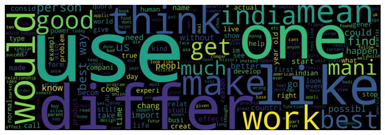

```python
question_cloud = WordCloud(width=1500,  height=500,
                               scale=3, background_color='black',
                               stopwords = ['new', 'amp', 'news', 'via', 'Û', 'u']).generate("".join(sincere_cloud), )

plt.figure(figsize=(10, 5))
plt.imshow(question_cloud, interpolation='bilinear')
plt.axis('off')
# plt.savefig('sincere wordcloud.png')
plt.show()
```

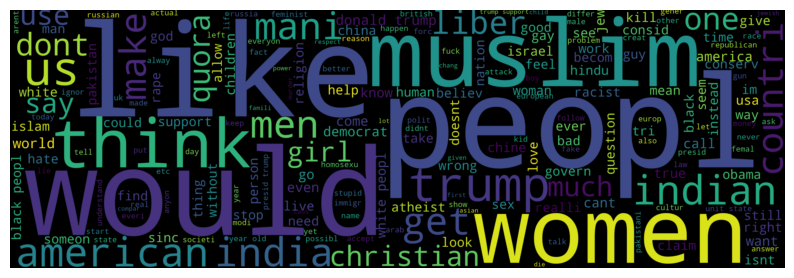

```python
question_cloud = WordCloud(width=1500,  height=500,
                               scale=3, background_color='black',
                               stopwords = ['new', 'amp', 'news', 'via', 'Û', 'u']).generate("".join(insincere_cloud), )

plt.figure(figsize=(10, 5))
plt.imshow(question_cloud, interpolation='bilinear')
plt.axis('off')
# plt.savefig('insincere wordcloud.png')
plt.show()
```

Czyli to czego można się było spodziewać - wojnę kulturowa, pytania o rasę i religię

```python
# with open('sincere_questions.txt', 'w') as f:
#     f.write(sincere_cloud)

# with open('insincere_questions.txt', 'w') as f:
#     f.write(insincere_cloud)
```

## CountVectorizer_ i _TF-IDF Vectorizer

**CountVectorizer** to narzędzie pozwalające na przetworzenie dokumentu tekstowego na matrycę tokenów. CountVectorizer buduje zasób słów, przypisując każdemu wyrazowi identyfikator i licząc ich częstość w każdym dokumencie tekstowym.

**TF-IDF** oznacza **Term Frequency-Inverse Document Frequency** - jest to metoda pozwalająca przypisać wagę słowom w zespole dokumentów . Waga wyrazu zależy od jego częstości w danym dokumencie **(TF)** oraz jego rzadkości **(IDF)** w całym zestawie dokumentów czyli w tzw. *korpus*. TF-IDF liczy się następująco: $$TF\;(Term \; Frequency) = \frac{Liczba \; wystąpień \; wyrazu \; T \; w \; zdaniu} {Całkowita \; liczba \; wyrazów \; w \; zdaniu}$$ $$IDF\;(Inverse \; Document \; Frequency) = log\;\frac{Całkowita \; liczba \; zdań \; w \; korpusie}{Liczba \; zdań \; z \; wyrazem \; T}$$ $$TF\text{-}IDF = TF \times IDF$$

**TF-IDF Vectorizer** to narzędzie, które umożliwia obliczenie wagi TF-IDF dla wyrazów w badanym zdaniu z danego korpusu. Cechy TF-IDF Vectorizer to:

- obniża wagę słów często występujących we wszystkich dokumentach tekstowych i zwiększa wagę wyrazów bardziej specyficznych dla mniejszych grup dokumentów
- można go wykorzystać do wyciągania pewnych wyrazów z danych, natomiast CountVectorizer służy przede wszystkim do przetwarzania danych w nauczaniu maszynowym
- ma pewne parametry do regulowania procesu np. minimalna lub maksymalna ilość wystąpień słowa w korpusie, żeby brać go pod uwagę

##### CountVectorizer:

```python
from sklearn.feature_extraction.text import CountVectorizer,TfidfVectorizer
import re
count_vect = CountVectorizer(max_features=200,
                             lowercase=True,
                             analyzer='word', # 'char' będzie po znakach, nie słowach
                             stop_words= 'english',
                             ngram_range=(1,3),
                             dtype=np.float32)

sample_q_df['fixed_questions']
count_vect_sample_docs_ = count_vect.fit_transform(sample_q_df['fixed_questions'])

count_vect_sample_docs_d = pd.DataFrame\
    .sparse\
    .from_spmatrix(count_vect_sample_docs_,
                   columns = count_vect.get_feature_names_out())

count_vect_sample_docs_d
```

|  | aaron | aaron brown | aaron brown solve | application | application number | application number ccrpwi | approve | approve delivered | approve delivered questionmark | article | ... | weak idprotocolname | weak idprotocolname delegate | website | website links | website links given | website small | website small startup | went | went wrong | went wrong questionmark |
| --- | --- | --- | --- | --- | --- | --- | --- | --- | --- | --- | --- | --- | --- | --- | --- | --- | --- | --- | --- | --- | --- |
| 0 | 1.0 | 1.0 | 1.0 | 0.0 | 0.0 | 0.0 | 0.0 | 0.0 | 0.0 | 0.0 | ... | 0.0 | 0.0 | 0.0 | 0.0 | 0.0 | 0.0 | 0.0 | 0.0 | 0.0 | 0.0 |
| 1 | 0.0 | 0.0 | 0.0 | 0.0 | 0.0 | 0.0 | 0.0 | 0.0 | 0.0 | 0.0 | ... | 0.0 | 0.0 | 2.0 | 1.0 | 1.0 | 1.0 | 1.0 | 0.0 | 0.0 | 0.0 |
| 2 | 0.0 | 0.0 | 0.0 | 0.0 | 0.0 | 0.0 | 0.0 | 0.0 | 0.0 | 1.0 | ... | 0.0 | 0.0 | 0.0 | 0.0 | 0.0 | 0.0 | 0.0 | 0.0 | 0.0 | 0.0 |
| 3 | 0.0 | 0.0 | 0.0 | 0.0 | 0.0 | 0.0 | 0.0 | 0.0 | 0.0 | 0.0 | ... | 0.0 | 0.0 | 0.0 | 0.0 | 0.0 | 0.0 | 0.0 | 0.0 | 0.0 | 0.0 |
| 4 | 0.0 | 0.0 | 0.0 | 0.0 | 0.0 | 0.0 | 0.0 | 0.0 | 0.0 | 0.0 | ... | 0.0 | 0.0 | 0.0 | 0.0 | 0.0 | 0.0 | 0.0 | 1.0 | 1.0 | 1.0 |
| 5 | 0.0 | 0.0 | 0.0 | 0.0 | 0.0 | 0.0 | 0.0 | 0.0 | 0.0 | 0.0 | ... | 0.0 | 0.0 | 0.0 | 0.0 | 0.0 | 0.0 | 0.0 | 0.0 | 0.0 | 0.0 |
| 6 | 0.0 | 0.0 | 0.0 | 0.0 | 0.0 | 0.0 | 0.0 | 0.0 | 0.0 | 0.0 | ... | 0.0 | 0.0 | 0.0 | 0.0 | 0.0 | 0.0 | 0.0 | 0.0 | 0.0 | 0.0 |
| 7 | 0.0 | 0.0 | 0.0 | 0.0 | 0.0 | 0.0 | 0.0 | 0.0 | 0.0 | 0.0 | ... | 1.0 | 1.0 | 0.0 | 0.0 | 0.0 | 0.0 | 0.0 | 0.0 | 0.0 | 0.0 |
| 8 | 0.0 | 0.0 | 0.0 | 0.0 | 0.0 | 0.0 | 0.0 | 0.0 | 0.0 | 0.0 | ... | 0.0 | 0.0 | 0.0 | 0.0 | 0.0 | 0.0 | 0.0 | 0.0 | 0.0 | 0.0 |
| 9 | 0.0 | 0.0 | 0.0 | 1.0 | 1.0 | 1.0 | 1.0 | 1.0 | 1.0 | 0.0 | ... | 0.0 | 0.0 | 0.0 | 0.0 | 0.0 | 0.0 | 0.0 | 0.0 | 0.0 | 0.0 |
| 10 | 0.0 | 0.0 | 0.0 | 0.0 | 0.0 | 0.0 | 0.0 | 0.0 | 0.0 | 0.0 | ... | 0.0 | 0.0 | 0.0 | 0.0 | 0.0 | 0.0 | 0.0 | 0.0 | 0.0 | 0.0 |
| 11 | 0.0 | 0.0 | 0.0 | 0.0 | 0.0 | 0.0 | 0.0 | 0.0 | 0.0 | 0.0 | ... | 0.0 | 0.0 | 0.0 | 0.0 | 0.0 | 0.0 | 0.0 | 0.0 | 0.0 | 0.0 |
| 12 | 1.0 | 1.0 | 1.0 | 0.0 | 0.0 | 0.0 | 0.0 | 0.0 | 0.0 | 0.0 | ... | 0.0 | 0.0 | 0.0 | 0.0 | 0.0 | 0.0 | 0.0 | 0.0 | 0.0 | 0.0 |

13 rows × 200 columns

##### TF-IDFVectorizer

```python
tfidf_vect = TfidfVectorizer(max_features=200,
                             lowercase=True,
                             analyzer='word', # tu też 'char' da po znakach
                             stop_words= 'english',
                             ngram_range=(1,3),
                             dtype=np.float32)

tfidf_vect_sample_docs_ = tfidf_vect.fit_transform(sample_q_df['fixed_questions'])

tfidf_vect_sample_docs_
```

```
<13x200 sparse matrix of type '<class 'numpy.float32'>'
	with 232 stored elements in Compressed Sparse Row format>
```

```python
# Lets decode sprase matrix
tfidf_vect_sample_docs_d = pd.DataFrame.sparse\
    .from_spmatrix(tfidf_vect_sample_docs_,
                   columns = tfidf_vect.get_feature_names_out())

# Print decoded dataframe
print(tfidf_vect_sample_docs_d.shape)
tfidf_vect_sample_docs_d
```

```
(13, 200)
```

|  | aaron | aaron brown | aaron brown solve | application | application number | application number ccrpwi | approve | approve delivered | approve delivered questionmark | article | ... | weak idprotocolname | weak idprotocolname delegate | website | website links | website links given | website small | website small startup | went | went wrong | went wrong questionmark |
| --- | --- | --- | --- | --- | --- | --- | --- | --- | --- | --- | --- | --- | --- | --- | --- | --- | --- | --- | --- | --- | --- |
| 0 | 0.247782 | 0.247782 | 0.247782 | 0.000000 | 0.000000 | 0.000000 | 0.000000 | 0.000000 | 0.000000 | 0.000000 | ... | 0.000000 | 0.000000 | 0.000000 | 0.000000 | 0.000000 | 0.000000 | 0.000000 | 0.000000 | 0.000000 | 0.000000 |
| 1 | 0.000000 | 0.000000 | 0.000000 | 0.000000 | 0.000000 | 0.000000 | 0.000000 | 0.000000 | 0.000000 | 0.000000 | ... | 0.000000 | 0.000000 | 0.391233 | 0.195617 | 0.195617 | 0.195617 | 0.195617 | 0.000000 | 0.000000 | 0.000000 |
| 2 | 0.000000 | 0.000000 | 0.000000 | 0.000000 | 0.000000 | 0.000000 | 0.000000 | 0.000000 | 0.000000 | 0.417259 | ... | 0.000000 | 0.000000 | 0.000000 | 0.000000 | 0.000000 | 0.000000 | 0.000000 | 0.000000 | 0.000000 | 0.000000 |
| 3 | 0.000000 | 0.000000 | 0.000000 | 0.000000 | 0.000000 | 0.000000 | 0.000000 | 0.000000 | 0.000000 | 0.000000 | ... | 0.000000 | 0.000000 | 0.000000 | 0.000000 | 0.000000 | 0.000000 | 0.000000 | 0.000000 | 0.000000 | 0.000000 |
| 4 | 0.000000 | 0.000000 | 0.000000 | 0.000000 | 0.000000 | 0.000000 | 0.000000 | 0.000000 | 0.000000 | 0.000000 | ... | 0.000000 | 0.000000 | 0.000000 | 0.000000 | 0.000000 | 0.000000 | 0.000000 | 0.287089 | 0.287089 | 0.287089 |
| 5 | 0.000000 | 0.000000 | 0.000000 | 0.000000 | 0.000000 | 0.000000 | 0.000000 | 0.000000 | 0.000000 | 0.000000 | ... | 0.000000 | 0.000000 | 0.000000 | 0.000000 | 0.000000 | 0.000000 | 0.000000 | 0.000000 | 0.000000 | 0.000000 |
| 6 | 0.000000 | 0.000000 | 0.000000 | 0.000000 | 0.000000 | 0.000000 | 0.000000 | 0.000000 | 0.000000 | 0.000000 | ... | 0.000000 | 0.000000 | 0.000000 | 0.000000 | 0.000000 | 0.000000 | 0.000000 | 0.000000 | 0.000000 | 0.000000 |
| 7 | 0.000000 | 0.000000 | 0.000000 | 0.000000 | 0.000000 | 0.000000 | 0.000000 | 0.000000 | 0.000000 | 0.000000 | ... | 0.266001 | 0.266001 | 0.000000 | 0.000000 | 0.000000 | 0.000000 | 0.000000 | 0.000000 | 0.000000 | 0.000000 |
| 8 | 0.000000 | 0.000000 | 0.000000 | 0.000000 | 0.000000 | 0.000000 | 0.000000 | 0.000000 | 0.000000 | 0.000000 | ... | 0.000000 | 0.000000 | 0.000000 | 0.000000 | 0.000000 | 0.000000 | 0.000000 | 0.000000 | 0.000000 | 0.000000 |
| 9 | 0.000000 | 0.000000 | 0.000000 | 0.136128 | 0.136128 | 0.136128 | 0.136128 | 0.136128 | 0.136128 | 0.000000 | ... | 0.000000 | 0.000000 | 0.000000 | 0.000000 | 0.000000 | 0.000000 | 0.000000 | 0.000000 | 0.000000 | 0.000000 |
| 10 | 0.000000 | 0.000000 | 0.000000 | 0.000000 | 0.000000 | 0.000000 | 0.000000 | 0.000000 | 0.000000 | 0.000000 | ... | 0.000000 | 0.000000 | 0.000000 | 0.000000 | 0.000000 | 0.000000 | 0.000000 | 0.000000 | 0.000000 | 0.000000 |
| 11 | 0.000000 | 0.000000 | 0.000000 | 0.000000 | 0.000000 | 0.000000 | 0.000000 | 0.000000 | 0.000000 | 0.000000 | ... | 0.000000 | 0.000000 | 0.000000 | 0.000000 | 0.000000 | 0.000000 | 0.000000 | 0.000000 | 0.000000 | 0.000000 |
| 12 | 0.247782 | 0.247782 | 0.247782 | 0.000000 | 0.000000 | 0.000000 | 0.000000 | 0.000000 | 0.000000 | 0.000000 | ... | 0.000000 | 0.000000 | 0.000000 | 0.000000 | 0.000000 | 0.000000 | 0.000000 | 0.000000 | 0.000000 | 0.000000 |

13 rows × 200 columns

# Modelowanie

Zostaną wykonane 4 modele:

- dwa proste - regresja logistyczna i XGBoost
- dwie sieci neuronowe, jedna bardziej złożona

Modele zostaną porównane przy pomocy **AUC**

```python
from sklearn.model_selection import train_test_split
from sklearn.linear_model import LogisticRegression
from sklearn.metrics import classification_report
from xgboost import XGBClassifier
```

```python
insincere_sample_questions_df = df.query('target == 1')
sincere_sample_questions_df = df.query('target == 0').sample(insincere_sample_questions_df.shape[0]) # sample z długością insincere żeby był stosunek pytań 50:50
```

```python
train_df = pd.concat([insincere_sample_questions_df, sincere_sample_questions_df], axis=0) # złożenie obu razem
train_df.shape
```

```
(161568, 6)
```

```python
X_train, X_test, y_train, y_test = train_test_split(train_df['filtered_questions'], train_df['target'], test_size=0.1, random_state=43)

test_question_iran = 'iranians free themselves'
X_test.str.contains(test_question_iran).any() # pytanie z wniosków dotyczące Irańczyków sprawdzimy po wytrenowaniu modelów, tutaj sprawdzenie czy to pytanie jest w zbiorze testowym
```

```
True
```

```python
print(X_train.shape, X_test.shape)
```

```
(145411,) (16157,)
```

```python
tfidf_vect = TfidfVectorizer(max_features=200,
                             lowercase=True,
                             analyzer='word', # inna opcja to 'char'
                             stop_words= 'english',
                             ngram_range=(1,3),
                             dtype=np.float32)
```

```python
# tworzymy zwektoryzowane zestawy treningowe i testowe
X_train_vect = tfidf_vect.fit_transform(X_train)
X_test_vect = tfidf_vect.transform(X_test)
```

```python
model_l = LogisticRegression(random_state = 1)
model_l.fit(X_train_vect, y_train)
```

```
LogisticRegression(random_state=1)
```

```python
params = {
    'objective': ['reg:squarederror', ],
    'max_depth': [8],
    'learning_rate': [0.1,],
    'n_estimators': [450]
}
```

```python
model_g = XGBClassifier(
    max_depth= 8,
    learning_rate= 0.1,
    n_estimators= 450)
model_g.fit(X_train_vect, y_train)
```

```
XGBClassifier(base_score=None, booster=None, callbacks=None,
              colsample_bylevel=None, colsample_bynode=None,
              colsample_bytree=None, device=None, early_stopping_rounds=None,
              enable_categorical=False, eval_metric=None, feature_types=None,
              gamma=None, grow_policy=None, importance_type=None,
              interaction_constraints=None, learning_rate=0.1, max_bin=None,
              max_cat_threshold=None, max_cat_to_onehot=None,
              max_delta_step=None, max_depth=8, max_leaves=None,
              min_child_weight=None, missing=nan, monotone_constraints=None,
              multi_strategy=None, n_estimators=450, n_jobs=None,
              num_parallel_tree=None, random_state=None, ...)
```

```python
model_l.predict_proba(X_test_vect), model_l.predict(X_test_vect)
```

```
(array([[0.66101219, 0.33898781],
        [0.5183628 , 0.4816372 ],
        [0.78240707, 0.21759293],
        ...,
        [0.24879226, 0.75120774],
        [0.03451033, 0.96548967],
        [0.67966011, 0.32033989]]),
 array([0, 0, 0, ..., 1, 1, 0], dtype=int8))
```

```python
import matplotlib.pyplot as plt
from sklearn.metrics import confusion_matrix, ConfusionMatrixDisplay
```

```python
pred = model_l.predict(X_test_vect)
pred_g = model_g.predict(X_test_vect)
```

```python
confusion_matrix_q = confusion_matrix(pred, y_test)
confusion_matrix_q
```

```
array([[6819, 2167],
       [1157, 6014]], dtype=int64)
```

```python
confusion_matrix(
    np.array([0, 0, 0, 0, 1, 0, 1, 1,]),
    np.array([0, 0, 0, 0, 1, 0, 0, 0]),
)
```

```
array([[5, 0],
       [2, 1]], dtype=int64)
```

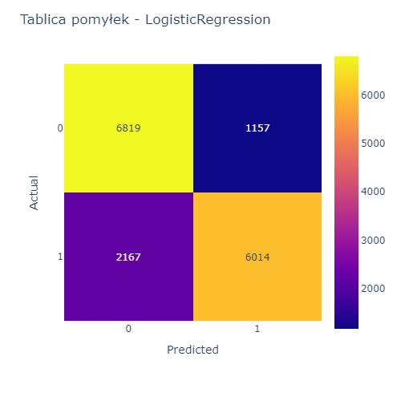

```python
# Create the confusion matrix
y_pred = pred
y_true = y_test
conf_matrix = confusion_matrix(y_true, y_pred)

# Create the plot
fig = px.imshow(conf_matrix, text_auto=True)

# Update x-axis to be at the top
fig.update_xaxes(side="bottom")

# Add labels
fig.update_layout(
    width=500, height=500,
    title='Tablica pomyłek - LogisticRegression',
    xaxis_title="Predicted",
    yaxis_title="Actual",
    xaxis=dict(
        tickmode="array",
        tickvals=[0, 1],  # Specify the desired tick values
        ticktext=["0", "1"],  # Specify the corresponding labels
    ),
    yaxis=dict(
        tickmode="array",
        tickvals=[0, 1],
        ticktext=["0", "1"],
    ),
)

# Show the plot
check_png(fig)
```

```python
print(classification_report(y_true, pred))
```

```
              precision    recall  f1-score   support

           0       0.76      0.85      0.80      7976
           1       0.84      0.74      0.78      8181

    accuracy                           0.79     16157
   macro avg       0.80      0.80      0.79     16157
weighted avg       0.80      0.79      0.79     16157
```

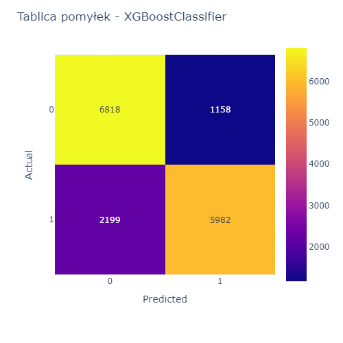

```python
y_pred = pred_g
y_true = y_test
conf_matrix = confusion_matrix(y_true, y_pred)

# Create the plot
fig = px.imshow(conf_matrix, text_auto=True)

# Update x-axis to be at the top
fig.update_xaxes(side="bottom")

# Add labels
fig.update_layout(
    width=500, height=500,
    title='Tablica pomyłek - XGBoostClassifier',
    xaxis_title="Predicted",
    yaxis_title="Actual",
    xaxis=dict(
        tickmode="array",
        tickvals=[0, 1],  # Specify the desired tick values
        ticktext=["0", "1"],  # Specify the corresponding labels
    ),
    yaxis=dict(
        tickmode="array",
        tickvals=[0, 1],
        ticktext=["0", "1"],
    ),
)

# Show the plot
check_png(fig)
```

```python
print(classification_report(y_true, pred_g))
```

```
              precision    recall  f1-score   support

           0       0.76      0.85      0.80      7976
           1       0.84      0.73      0.78      8181

    accuracy                           0.79     16157
   macro avg       0.80      0.79      0.79     16157
weighted avg       0.80      0.79      0.79     16157
```